# Assignment 7

Nick Andriese

2022-07-24

##Some of this is from my assignment 6 code

```r
#install.packages("car","gvlma", "MASS", "leaps")
library(car)
library(gvlma)
library(MASS)
library(leaps)
library(readr)
prprice <- read_csv("prop_prices_reduced.csv")
```

1. This time, I want you to separate your data into testing and training. For this exercise, randomly extract 100 for testing different models, and save the other 900 for training your models

```r
#Assignment07

#1
library(gamlr)
library(pROC)
```

```r
library(rpart)
library(rpart.plot)
library(party)
library(randomForest)
library(e1071)
library(psych)
set.seed(1234)
train <- sample(nrow(prprice[-7,-8]), 0.9*nrow(prprice[-7,-8]))

p.train <- prprice[train,-8]

p.train <- data.frame(p.train)

p.validate <- prprice[-train,-8]

p.validate <- data.frame(p.validate)
```

2. Run your final model you had in the previous assignment to the training data

```r
#2

train.model <- lm((sale_def^(.22)) ~ bed + bath + area_heated + area + dist_cbd, data = p.train)
summary(train.model)
```

```
##
## Call:
## lm(formula = (sale_def^(0.22)) ~ bed + bath + area_heated + area +
##     dist_cbd, data = p.train)
##
## Residuals:
##     Min      1Q  Median      3Q     Max
## -3.6747 -0.5273 -0.0353  0.4970  3.5794
##
## Coefficients:
##               Estimate Std. Error t value Pr(>|t|)
## (Intercept)  1.090e+01  1.456e-01  74.827  < 2e-16 ***
## bed         -2.373e-01  5.187e-02  -4.576 5.42e-06 ***
## bath         4.080e-01  7.153e-02   5.703 1.60e-08 ***
## area_heated  1.726e-03  6.714e-05  25.706  < 2e-16 ***
## area         1.417e-05  2.763e-06   5.129 3.58e-07 ***
## dist_cbd    -2.859e-05  5.002e-06  -5.716 1.48e-08 ***
## ---
## Signif. codes:  0 '***' 0.001 '**' 0.01 '*' 0.05 '.' 0.1 ' ' 1
##
## Residual standard error: 0.8819 on 893 degrees of freedom
## Multiple R-squared:  0.7826, Adjusted R-squared:  0.7814
## F-statistic:   643 on 5 and 893 DF,  p-value: < 2.2e-16
```

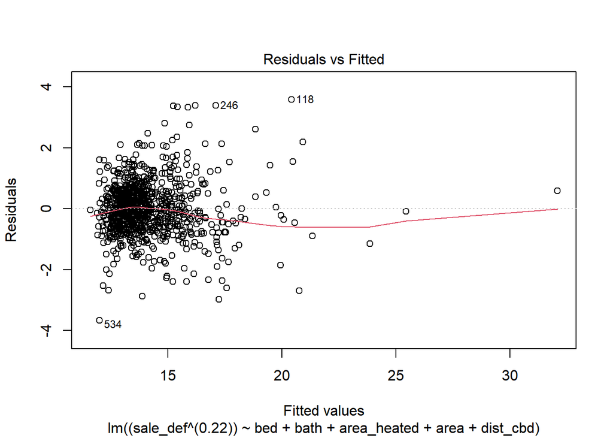

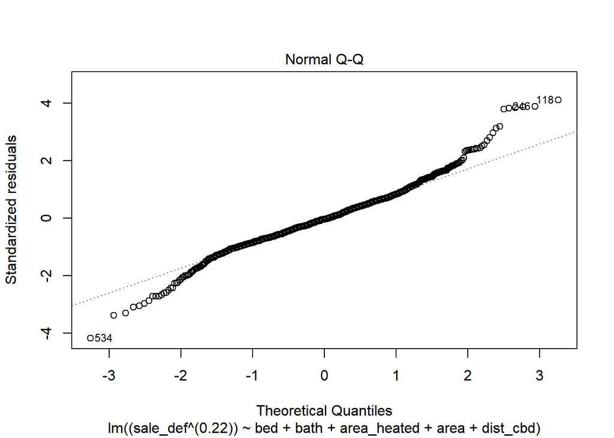

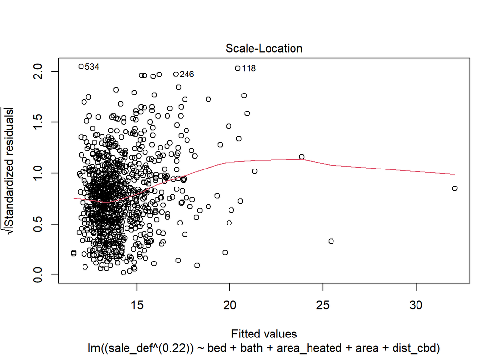

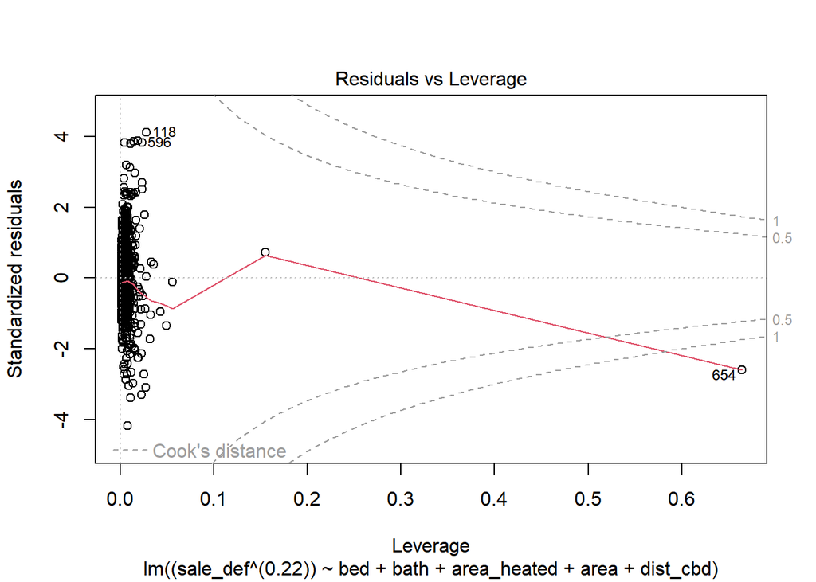

```r
plot(train.model)
```

```r
summary(gvlma(train.model))
```

```
##
## Call:
## lm(formula = (sale_def^(0.22)) ~ bed + bath + area_heated + area +
##     dist_cbd, data = p.train)
##
## Residuals:
##     Min      1Q  Median      3Q     Max
## -3.6747 -0.5273 -0.0353  0.4970  3.5794
##
## Coefficients:
##               Estimate Std. Error t value Pr(>|t|)
## (Intercept)  1.090e+01  1.456e-01  74.827  < 2e-16 ***
## bed         -2.373e-01  5.187e-02  -4.576 5.42e-06 ***
## bath         4.080e-01  7.153e-02   5.703 1.60e-08 ***
## area_heated  1.726e-03  6.714e-05  25.706  < 2e-16 ***
## area         1.417e-05  2.763e-06   5.129 3.58e-07 ***
## dist_cbd    -2.859e-05  5.002e-06  -5.716 1.48e-08 ***
## ---
## Signif. codes:  0 '***' 0.001 '**' 0.01 '*' 0.05 '.' 0.1 ' ' 1
##
## Residual standard error: 0.8819 on 893 degrees of freedom
## Multiple R-squared:  0.7826, Adjusted R-squared:  0.7814
## F-statistic:   643 on 5 and 893 DF,  p-value: < 2.2e-16
##
##
## ASSESSMENT OF THE LINEAR MODEL ASSUMPTIONS
## USING THE GLOBAL TEST ON 4 DEGREES-OF-FREEDOM:
## Level of Significance =  0.05
##
## Call:
##  gvlma(x = train.model)
##
##                        Value  p-value                   Decision
## Global Stat        154.70783 0.000000 Assumptions NOT satisfied!
## Skewness             9.28170 0.002315 Assumptions NOT satisfied!
## Kurtosis           143.63860 0.000000 Assumptions NOT satisfied!
## Link Function        0.02676 0.870062    Assumptions acceptable.
## Heteroscedasticity   1.76076 0.184529    Assumptions acceptable.
```

3. With the same model in part 2, run the standard LASSO regression model on the training data.

```r
?gamlr
```

```
## starting httpd help server ... done
```

```r
data(p.train)
```

```r
x <- cbind(p.train$bed, p.train$bath, p.train$area_heated, p.train$area, p.train$dist_cbd, p.train$dist_lakes)
reg <- gamlr(x, p.train$sale_def^.22, verb = TRUE, standardize = TRUE)
```

[output not shown]

[output cut: 46 more lines]

[output not shown]

```r
exp(coef(reg)[1])
```

```
## [1] 48970.16
```

4. Now using the same model in part 2, run a 10-fold cross-validated LASSO on the training data

```r
#Lasso 10 fold cross validation

cv.reg <- cv.gamlr(x, p.train$sale_def^.22, nfold = 10, verb = TRUE, standardize = TRUE)
```

```
## fold 1,2,3,4,5,6,7,8,9,10,done.
```

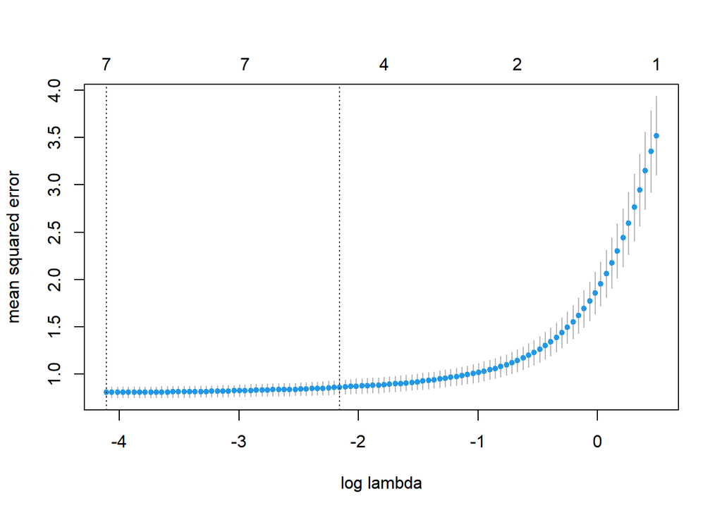

```r
par(mfrow = c(1,1))
plot(cv.reg)
```